# HW 12

ES 218

> Before completing this assignment, make sure to read through the [Base plotting environment](http://mgimond.github.io/ES218/Week04a.html) tutorial and the [Customizing colors](http://mgimond.github.io/ES218/Week04d.html) section on the course website. It may also be helpful to review [factors and their levels](http://mgimond.github.io/ES218/Week02a.html#Factor) from Week 2.

In this assignment, you will write an R script that will generate three plots using the base plotting environment. You will limit your code to packages and functions covered thus far in class and in the tutorials. You will upload your completed (and commented) script to Moodle.

## Plot 1

Using the ACS.csv data file from http://mgimond.github.io/ES218/Data/ACS.csv, you will recreate the following scatter plot of median household income vs. percent of the entire county population (i.e. not broken down by labor force) having attained a bachelor’s degree or greater. Refer to the [Codebook](https://mgimond.github.io/ES218/Data/ACS_CodeBook.csv) for variable descriptions. Variables that end in `***s` are standard error values. Those that do not are the estimates. This operation will require that you compute a percentage value from the educational attainment count estimates (the ACS values represent population counts).

Note that each point in the plot represents a county. The points are symbolized using a transparency of 90% (or 10% opaqueness). Note that the tic marks may change based on the graphic window size–you will not concern yourself with this detail.

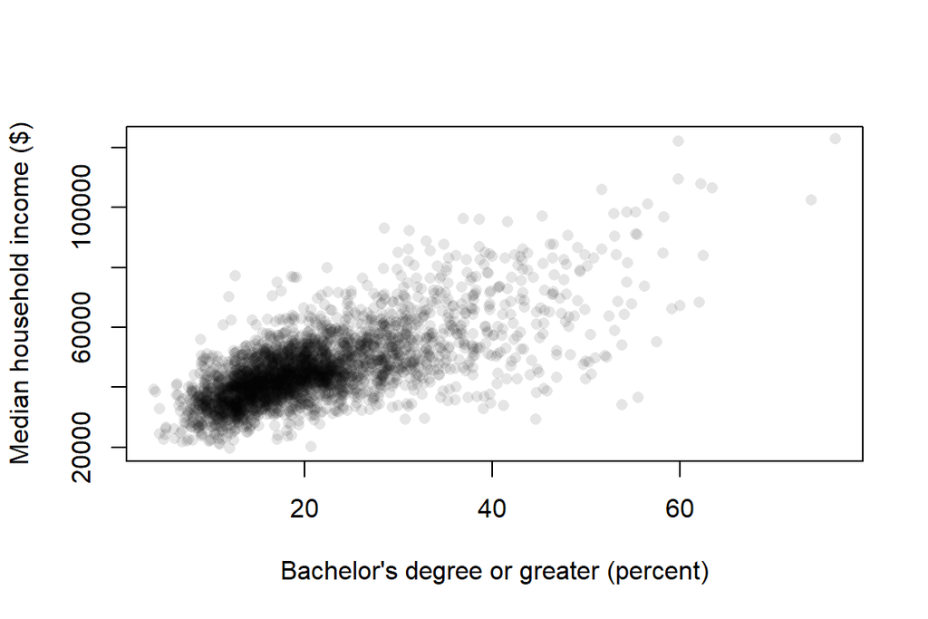

## Plot 2

Continuing with the ACS data, you will recreate the following plot where the boxplots are ordered by median state income values. You will limit the states to `me`, `nh`, `vt`, `ma`, `ri`, `ct` and `ny`.

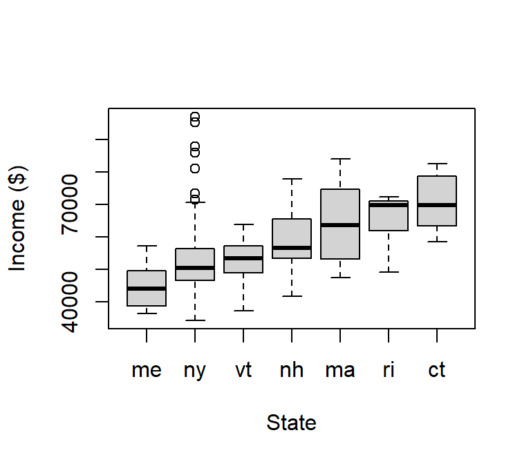